# Proyecciones y estimaciones de tiempo de duplicación

Grupo covid19UNGS

27 June, 2020

# Estimación de cambios en el número reproductivo efectivo $R_t$

- Datos a partir de los reportes del Ministerio de Salud

El valor de $R_t$ representa el número esperado de casos secundarios que surgen de un caso primario infectado en el momento $t$. Este valor cambia a lo largo de un brote. Si el valor de $R_t$ permanece por debajo de uno, el brote se extinguirá. Sin embargo, cuando $R_t$ es mayor que uno, es probable que se produzca un brote sostenido. El objetivo de las intervenciones de control es típicamente reducir el número de reproducción por debajo de uno (Thompson et al. 2019).

Método de estimación aplicado (A. Cori et al. 2013; Thompson et al. 2019) permite la inclusión de los casos importados y que se puede estimar el intervalo serial a partir de seguimiento de casos y también incluir variablidad en la distribucion del intervalo serial cuando se asume una distribución gamma discreta.

- Un parametro importante es el ‘Serial interval’ (SI). El SI es el tiempo entre el inicio de los síntomas de cada caso de la enfermedad en cuestión, y el inicio de los síntomas en cualquier caso secundario que resulte de la transmisión de los casos primarios. En otras palabras, es el tiempo entre casos en la cadena (de ramificación) de transmisión de la enfermedad. El SI es, de hecho, una distribución estadística de tiempos de intervalo en serie, en lugar de un valor fijo. Esa distribución se puede simular, generalmente utilizando una distribución gamma discreta con una media y desviación estándar dada.
- Se utilizó un ‘Serial interval’ (SI) estimado por Q. Li et al. (2020) basado en 16 casos es de 7.5 días, con una SD=3.4, pero se permitió que la media del SI variara entre 2.3 y 8.4 usando una distribución normal truncada con una SD de 2.0, y tambien variamos la SD de la SD que variara entre 0.5 y 4.0
- Luego se estimó el intervalo serial basandose en los datos de He et al. (2020) (77 casos), con una media estimada en su paper de 5.8 días, aunque esta dentro de los parámetros del punto anterior estos datos serían más realistas.

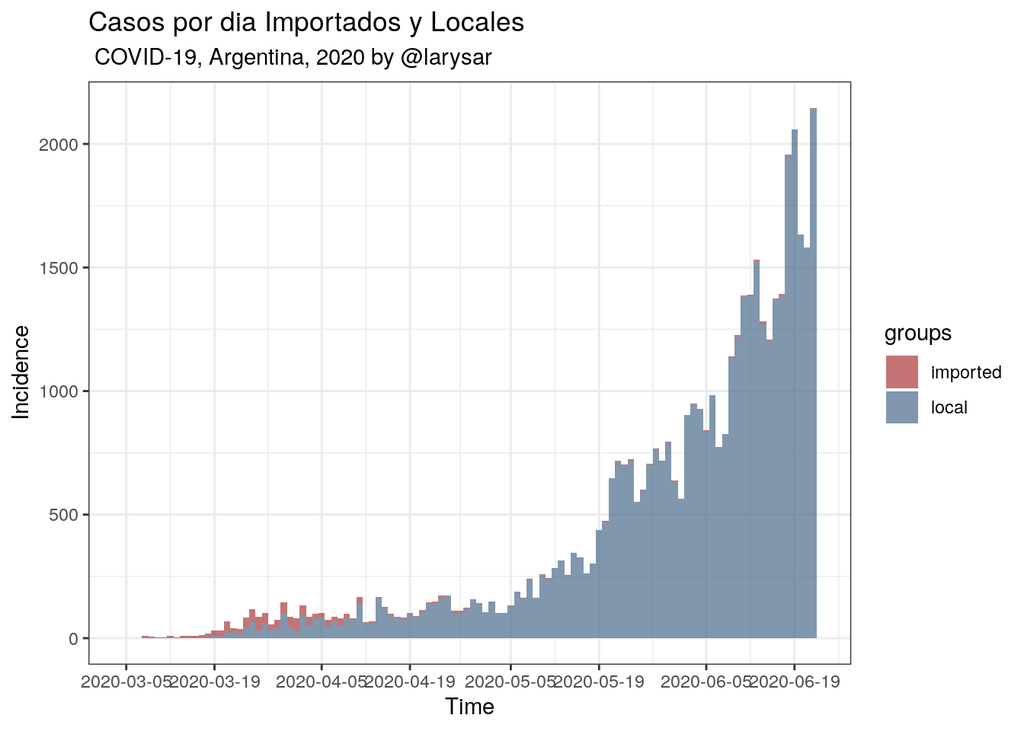

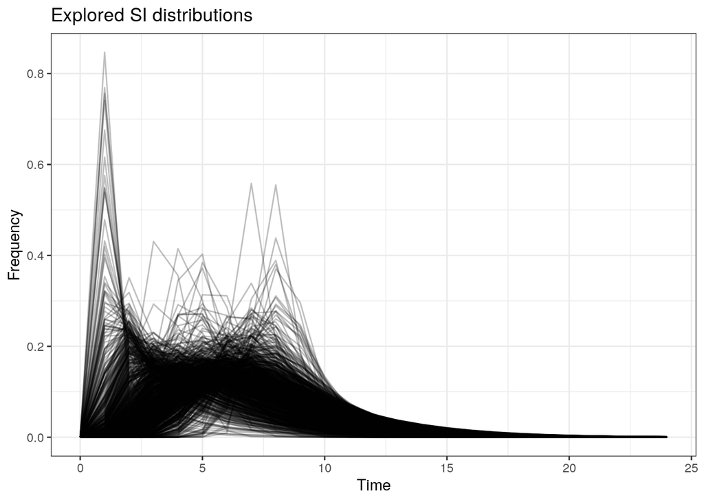

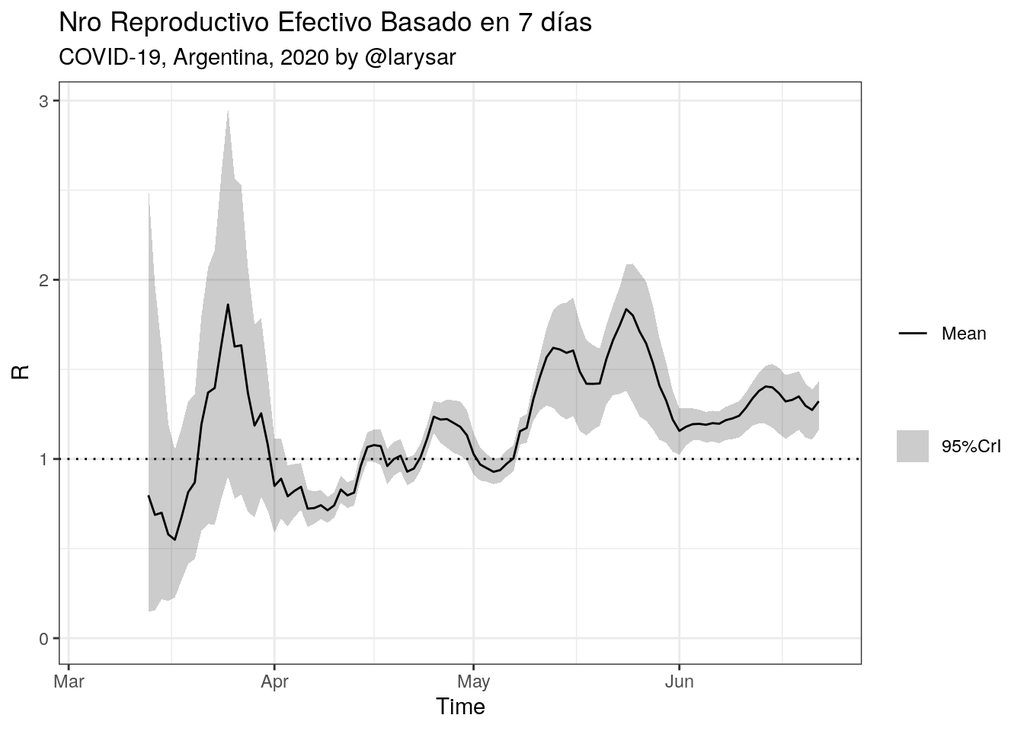

## Variación en el intervalo serial

- Usamos los datos de He et al. (2020) (77 casos) para estimar el intervalo serial (SI media de 5.8) y el $R_t$, hay que eliminar el par con ID=9 porque el infector y el infectado suceden el mismo día. Estos datos consisten en la fecha de inicio de los síntomas en casos primarios y la fecha de inicio de síntomas en casos secundarios (originados por los primarios)

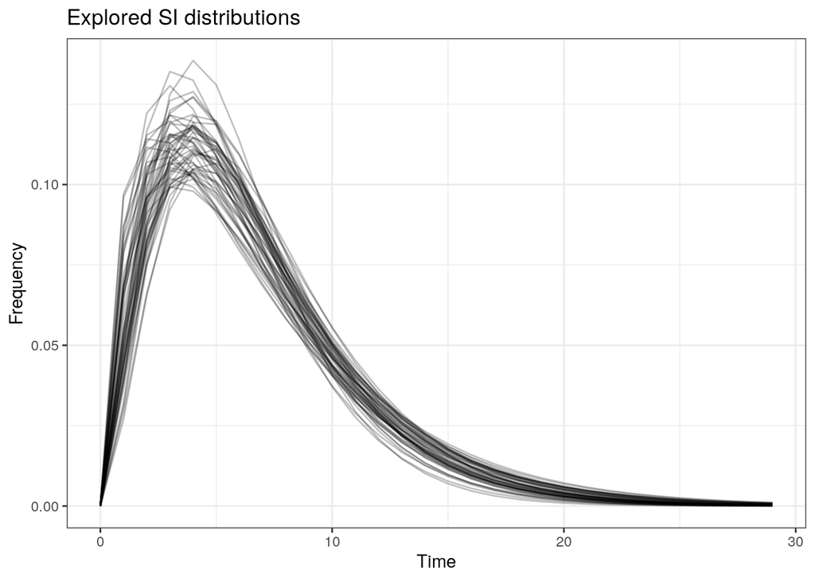

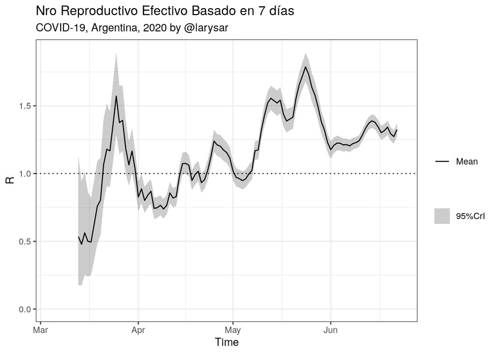

La mediana del intervalo serial estimado es **mu =6.6944741** y la desviación **sigma =4.4140809**, lo cual es diferente de lo reportado en el paper de He et al. (2020) seguramente debido a que se usaron diferentes métodos. De ahora en adelante usaremos el intervalo serial estimado por nosotros.

## Estimaciones usando modelos log-lineales

La fase inicial de un brote, cuando se muestra en un gráfico de semi-log (el eje y con una transformación logarítmica), aparece (algo) lineal. Esto sugiere que podemos modelar el crecimiento y decaimiento epidémico, utilizando un modelo log-lineal simple de la forma:

$$log(y) = rt + b$$

donde $y$ es la incidencia, $r$ es la tasa de crecimiento, $t$ es el número de días desde un punto específico en el tiempo (generalmente el inicio del brote) y $b$ es la ordenada de origen. Se ajustan modelos separados para distintas fases de la curva de epidemia (datos de incidencia).

- Dividimos la curva de incidencia en dos partes, antes y despues del primer pico de incidencia que sucedió despues de la cuarentena (20/03/2020), que resultó el 30/03/2020. Tomamos esta fecha para determinar el $R_0$ antes de la cuarentena

### Estimamos con los casos locales (no importados) para toda Argentina

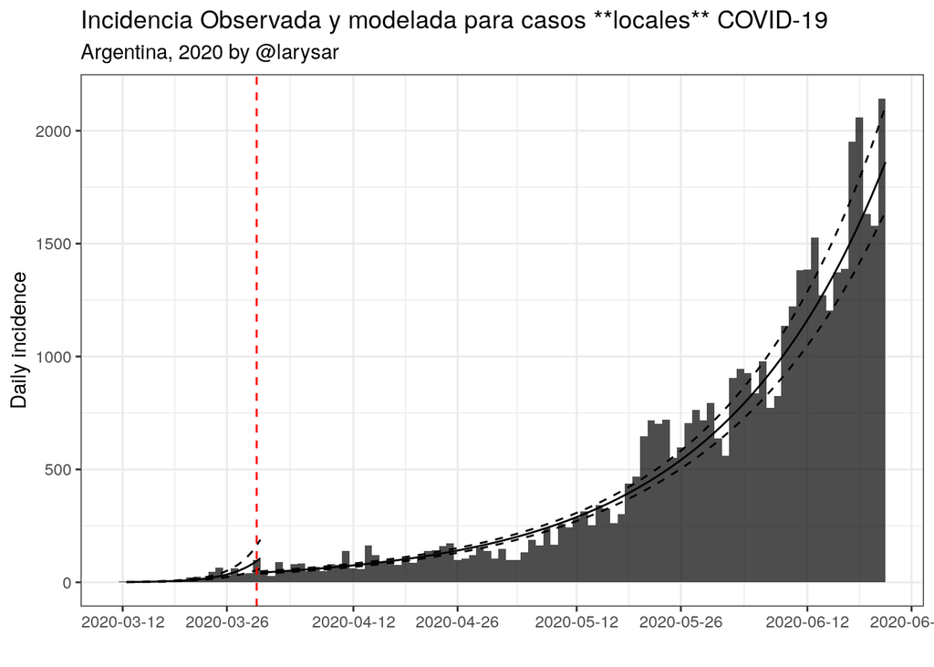

- La tasa de crecimiento antes del pico **2020-03-30** fue **0.25** (95% CI 0.20 - 0.31)
- La tasa de crecimiento después el pico fue **0.045** (95% CI 0.0475 - 0.0423).
- El tiempo de duplicacion de la primer parte es es **2.8 días** (95% CI 2.3 - 3.5 días)
- El tiempo de duplicación de la segunda parte **15.4 días** (95% CI 14.6 - 16.4 días).

## Proyecciones de incidencia para el total de casos Argentina

- Esta estimación de proyecciones requiere la estimación del R0 para las dos fases que definimos (con division en el primer pico después de la cuarentena 2020-03-30), basado en (Nouvellet et al. 2018). Tomamos solamente los casos locales.
- Utilizamos los datos sobre la incidencia diaria, *el intervalo de serial* (tiempo entre el inicio de los infectores y los infectados) y el número de reproductivo, que se mantiene constante, para simular trayectorias de epidemia plausibles y proyectar la incidencia futura. Se basa en un proceso de ramificación donde la incidencia diaria sigue un proceso de Poisson determinado por una infecciosidad diaria, calculada como:

$$\lambda_t \sim Pois \left ( \sum_{s=1}^{t-1} y_s w(t-s) \right )$$

donde $w()$ es la función de masa de probabilidad del intervalo serial, y $y_s$ es la incidencia en el tiempo $s$.

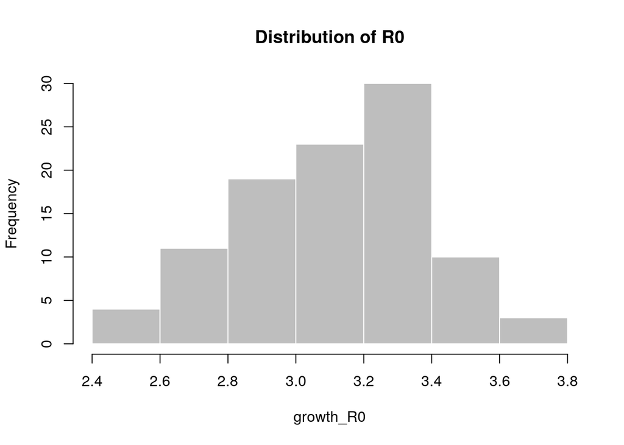

```
##    Min. 1st Qu.  Median    Mean 3rd Qu.    Max.
##   2.428   2.945   3.120   3.115   3.305   3.769
```

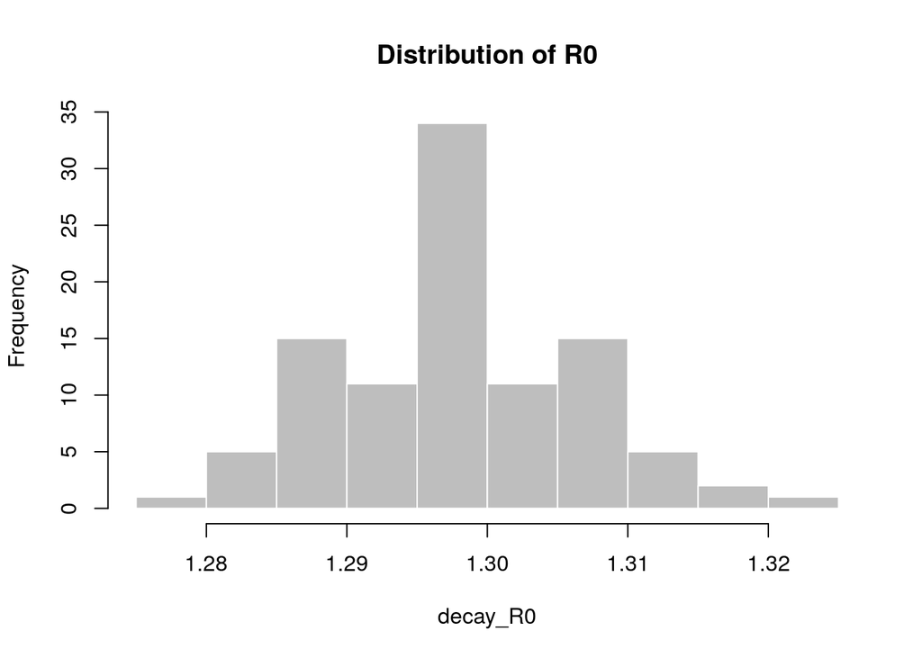

```
##    Min. 1st Qu.  Median    Mean 3rd Qu.    Max.
##   1.275   1.293   1.298   1.298   1.304   1.322
```

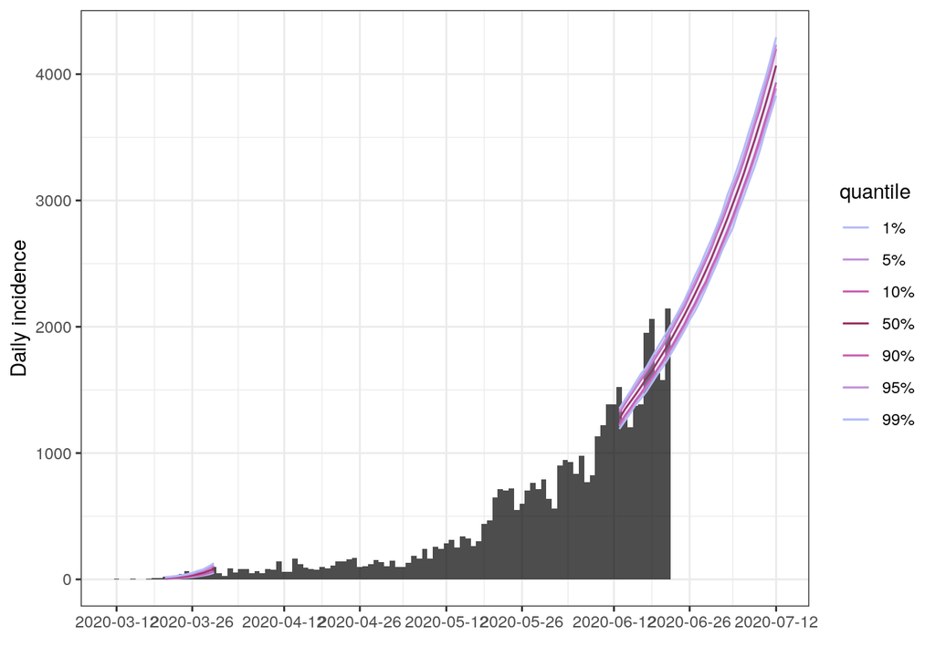

## El $R_0$ y la heterogeneidad de la epidemia

Habiendo hecho todos los calculos anteriores tenemos que aclarar que los análisis basados en el $R_0$ (el número de reproducción básico, el número esperado de casos secundarios producida por un caso primario durante su período infeccioso en una población completamente susceptible (Kermack, McKendrick, and Walker 1927)) tienen una serie de susposiciones que no se cumplen (Hébert-Dufresne et al. 2020).Esto se puede razonar de la siguiente forma, el $R_0$ nos dice el número de infecciones producidas por un caso pero ese numero promedio tiene una gran variación (Lloyd-Smith et al. 2005). Hay situaciones en las que se producen los eventos de super-propagación que están relacionadas con individuos que tienen mayor carga viral, o mayores contactos, o situaciones en las que se propicia la transmición (encuentros de muchas personas sin distancimiento ni protección). Es decir, puede ser engañoso mirar promedios provinciales o nacionales y celebrar si $R_0$ parece estar cayendo por debajo de 1 porque la epidemia podría estar causando estragos en lugares deteminados o entre grupos particulares. Digamos que incluso si $R_0$ está por debajo de 1 se pueden producir brotes grandes debido a la super-propagación o simplemente por casualidad.

## Estimación de $R_t$ y tiempo de duplicación para Ciudad de Buenos Aires CABA

- La linea punteada marron vertical es pico de casos local, luego las lineas punteadas rojas son las fases de la cuarentena del gobierno nacional https://www.argentina.gob.ar/coronavirus/aislamiento/fases, hasta el ASPO/DISPO https://www.boletinoficial.gob.ar/detalleAviso/primera/230245/20200608.
- Datos a partir de los reportes del Ministerio de Salud

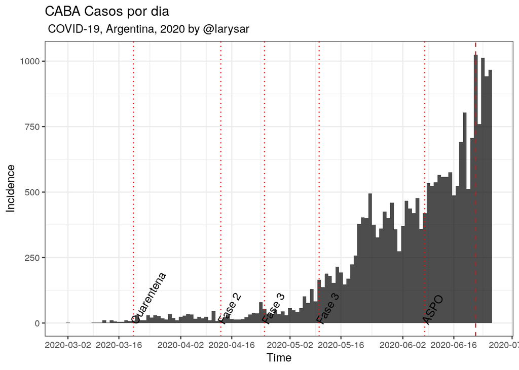

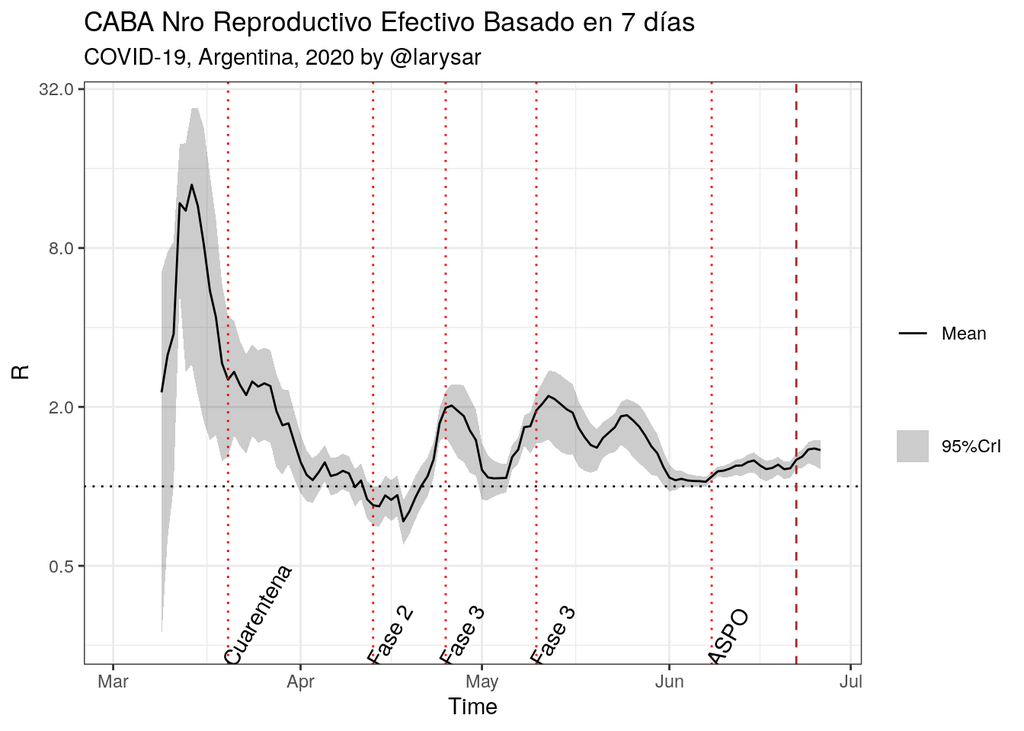

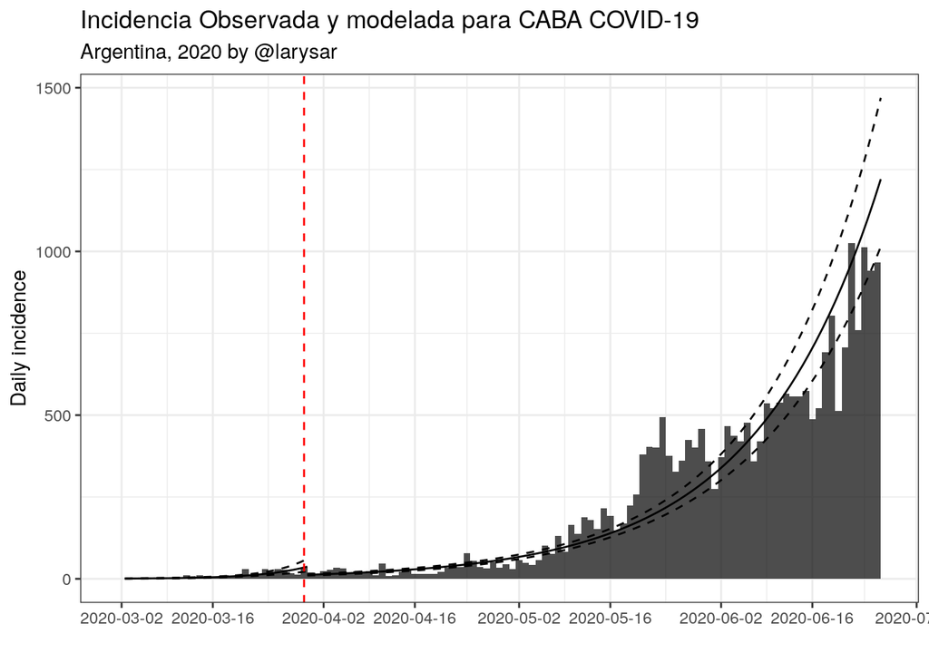

- La tasa de crecimiento antes del pico **2020-03-30** fue **0.14** (95% CI 0.10 - 0.18)
- La tasa de crecimiento después el pico fue **0.052** (95% CI 0.0559 - 0.0487).
- El tiempo de duplicación de la primer parte es es **5.0 días** (95% CI 3.9 - 6.8 días)
- El tiempo de duplicación de la segunda parte **13.3 días** (95% CI 12.4 - 14.2 días).

### Proyecciones de Incidencia para CABA

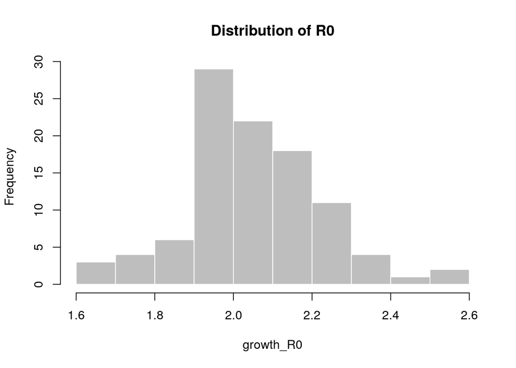

```
##    Min. 1st Qu.  Median    Mean 3rd Qu.    Max.
##   1.610   1.938   2.034   2.048   2.151   2.581
```

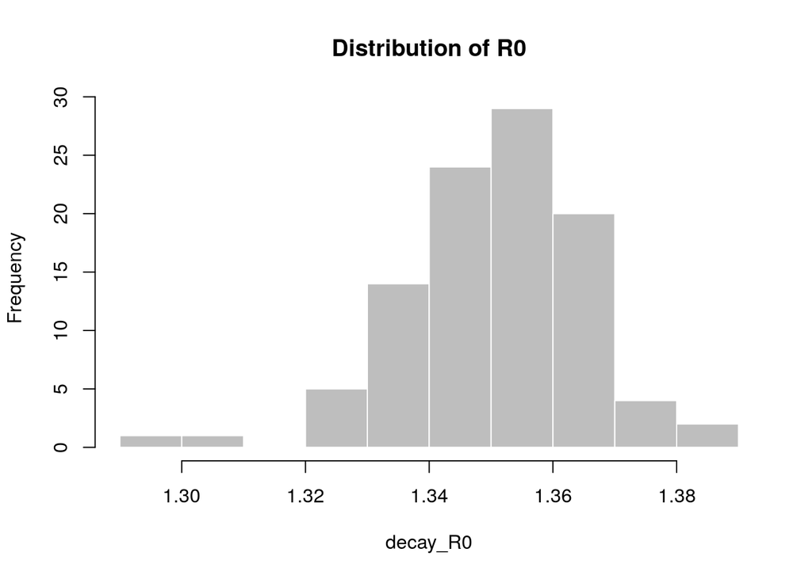

```
##    Min. 1st Qu.  Median    Mean 3rd Qu.    Max.
##   1.292   1.343   1.351   1.351   1.360   1.387
```

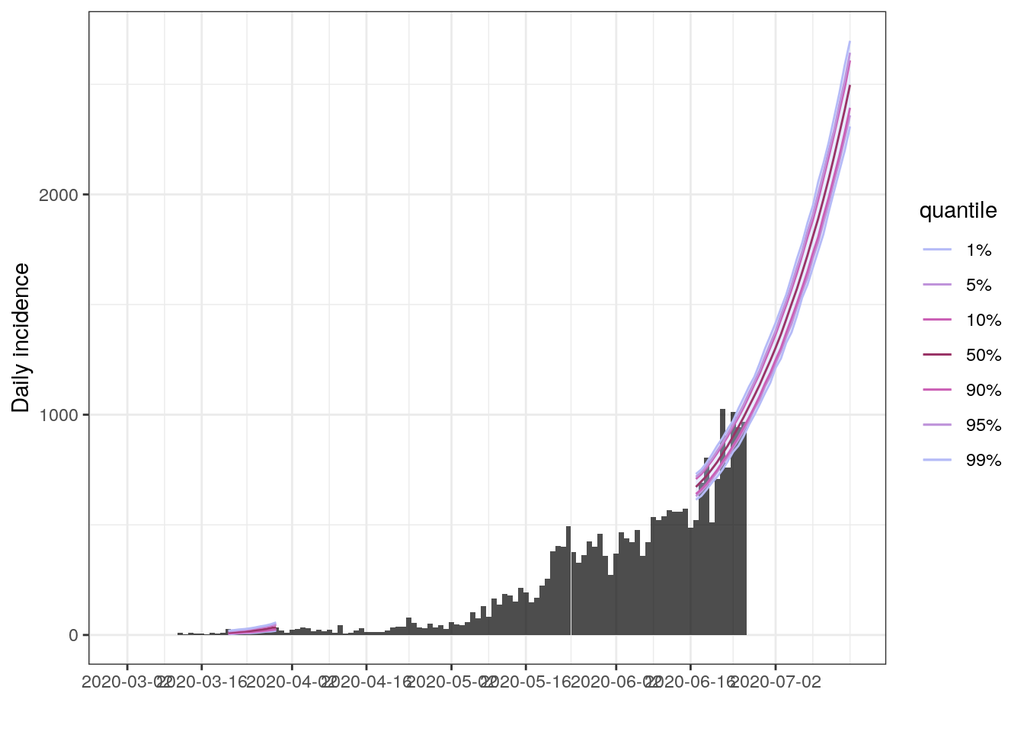

## Estimación de $R_t$ y tiempo de duplicación para Ciudad de Buenos Aires CABA a partir de Datos Abiertos

- Tomando los [Datos abiertos del ministerio de salud](http://datos.salud.gob.ar/dataset/covid-19-casos-registrados-en-la-republica-argentina/archivo/fd657d02-a33a-498b-a91b-2ef1a68b8d16)
- Enlace de descarga directo https://sisa.msal.gov.ar/datos/descargas/covid-19/files/Covid19Casos.csv
- Última fecha de actualización 2020-06-26
- Los datos se actualizan por día a las 17:45, para los calculos de $R_t$ tomo el día anterior debido a que para el ultimo día no se contabilizan todos los casos.

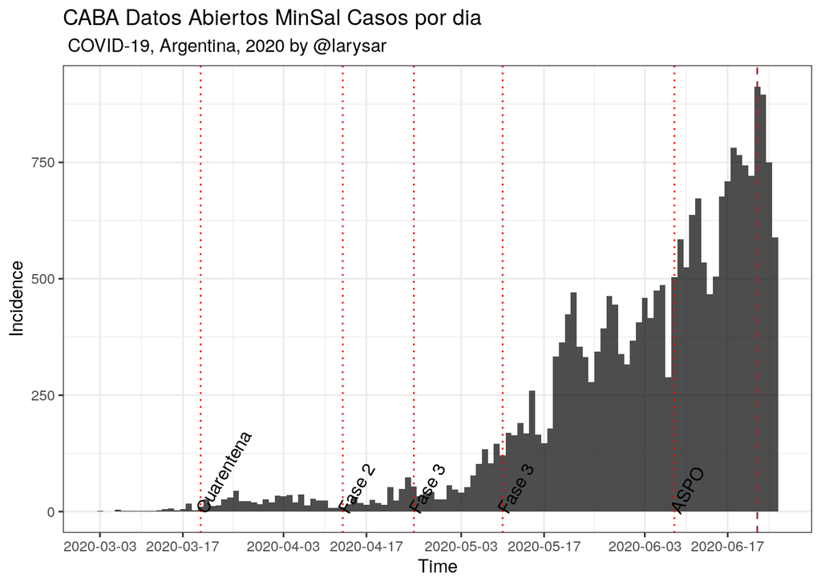

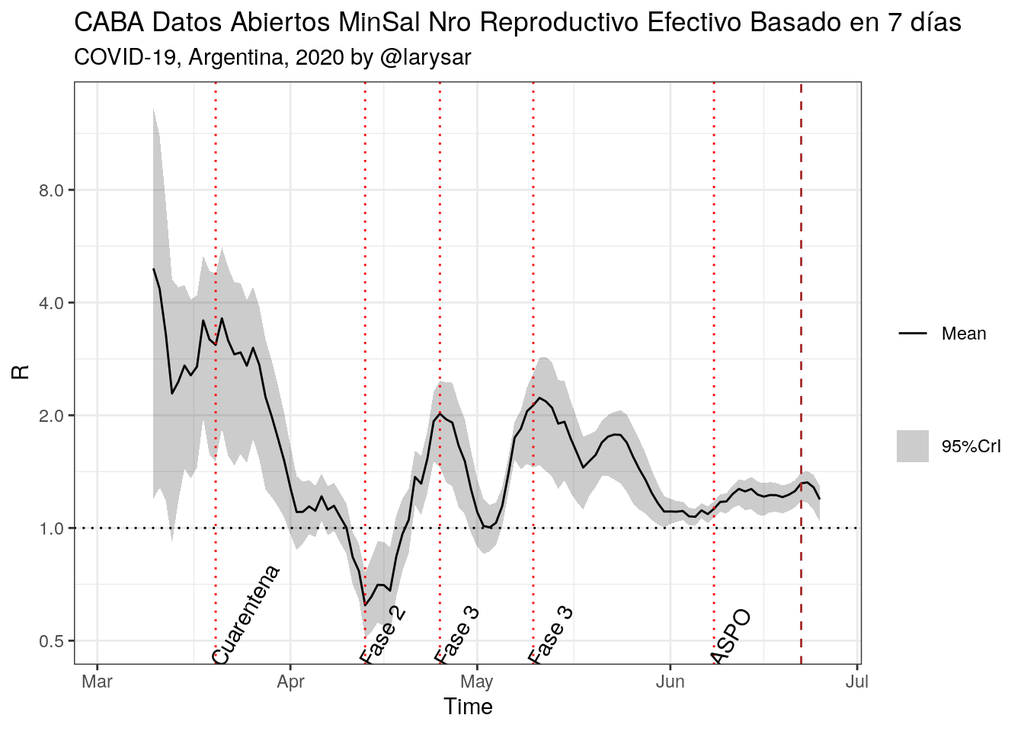

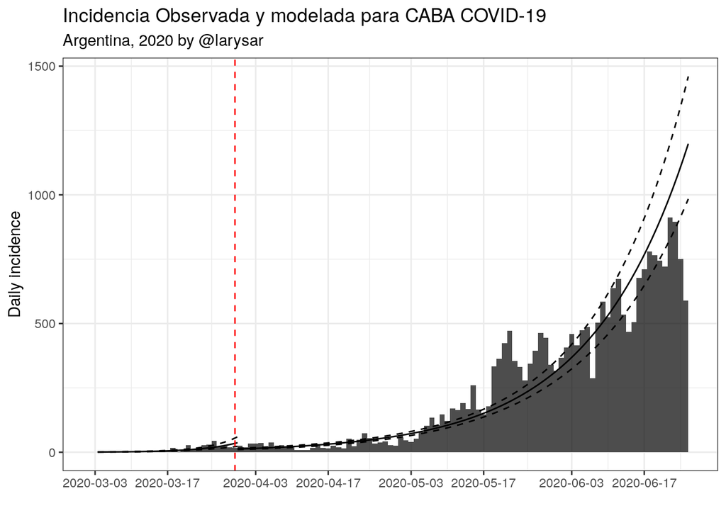

- La tasa de crecimiento antes del pico **2020-03-30** fue **0.14** (95% CI 0.11 - 0.17)
- La tasa de crecimiento después el pico fue **0.052** (95% CI 0.0563 - 0.0485).
- El tiempo de duplicación de la primer parte es es **4.9 días** (95% CI 4.0 - 6.3 días)
- El tiempo de duplicación de la segunda parte **13.2 días** (95% CI 12.3 - 14.3 días).

## Estimación de $R_t$ y tiempo de duplicación para Prov. de Buenos Aires

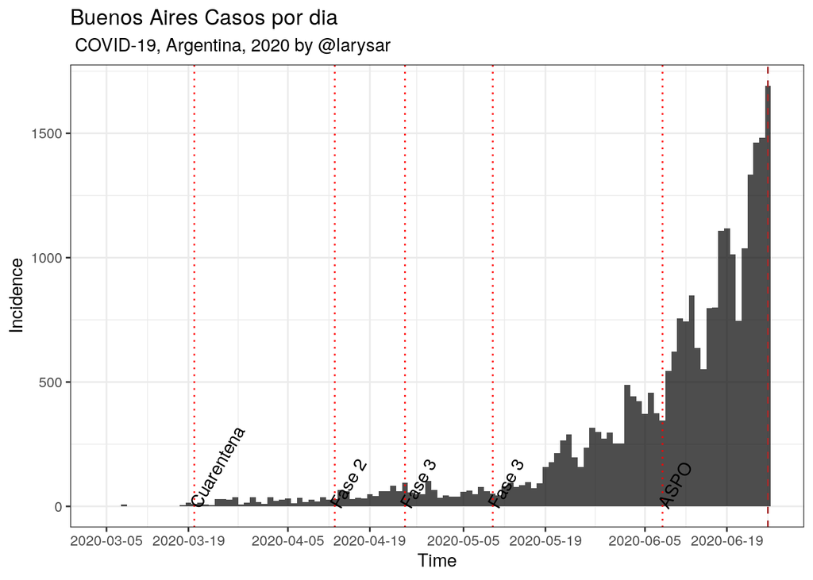

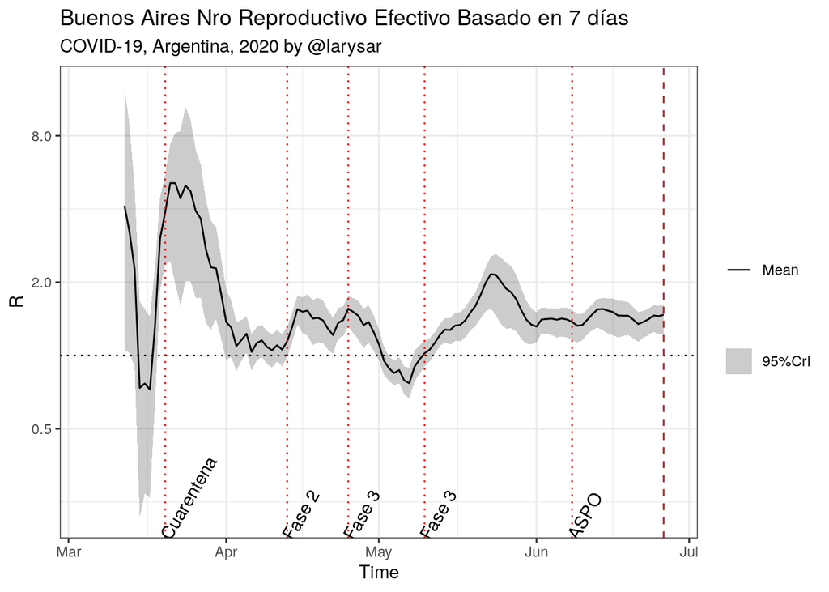

- Luego estimamos modelos log-lineales

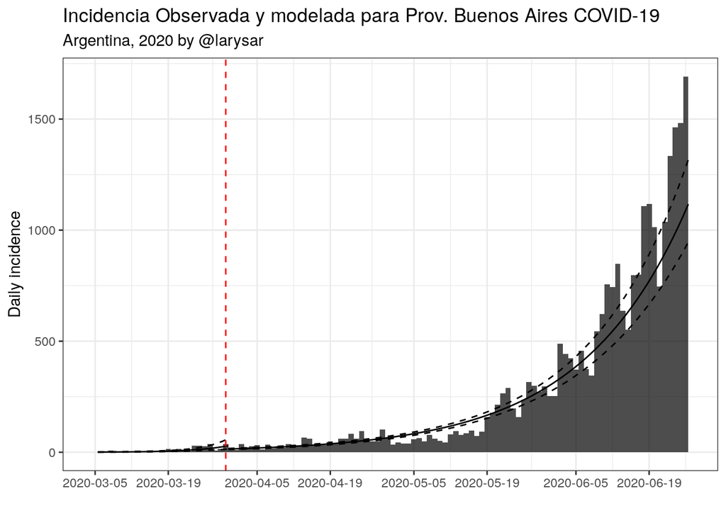

- La tasa de crecimiento antes del pico **2020-03-30** fue **0.15** (95% CI 0.093 - 0.21)
- La tasa de crecimiento después el pico fue **0.049** (95% CI 0.0527 - 0.0462).
- El tiempo de duplicación de la primer parte es es **4.6 días** (95% CI 3.3 - 7.5 días)
- El tiempo de duplicación de la segunda parte **14.0 días** (95% CI 13.2 - 15.0 días).

### Calculo de Proyecciones de Incidencia para Prov. De Buenos Aires

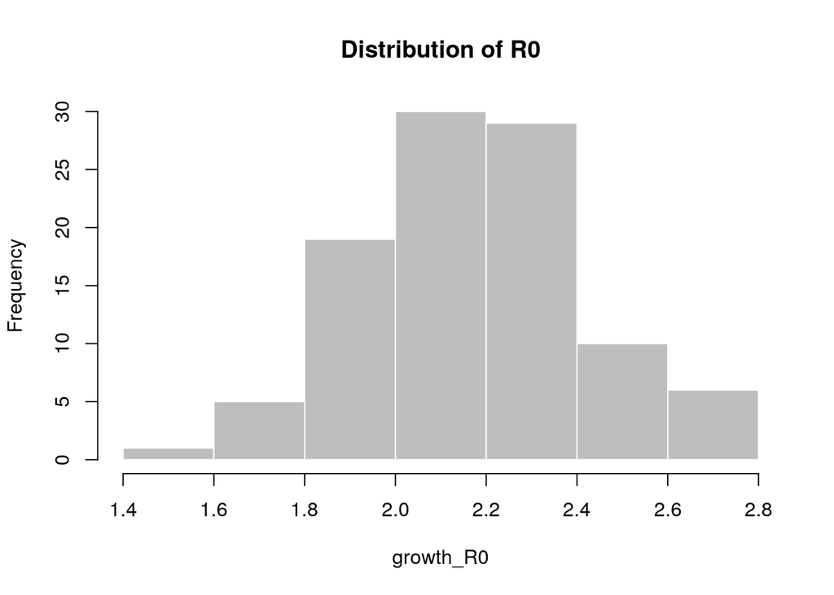

```
##    Min. 1st Qu.  Median    Mean 3rd Qu.    Max.
##   1.521   1.994   2.169   2.169   2.341   2.705
```

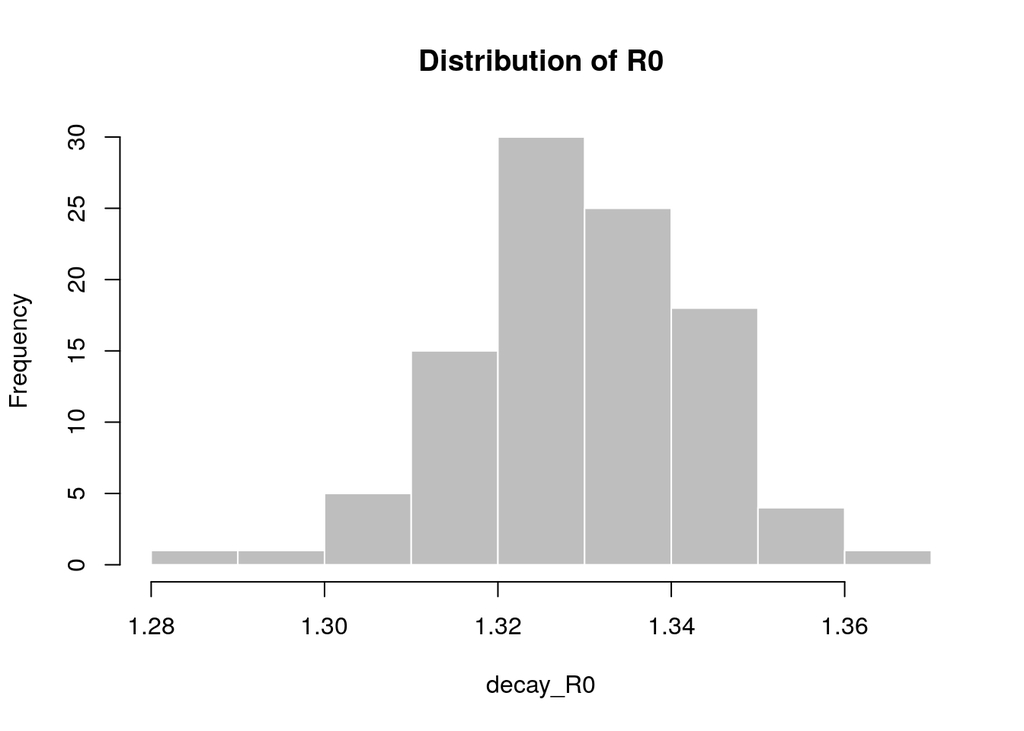

```
##    Min. 1st Qu.  Median    Mean 3rd Qu.    Max.
##   1.285   1.322   1.330   1.330   1.339   1.366
```

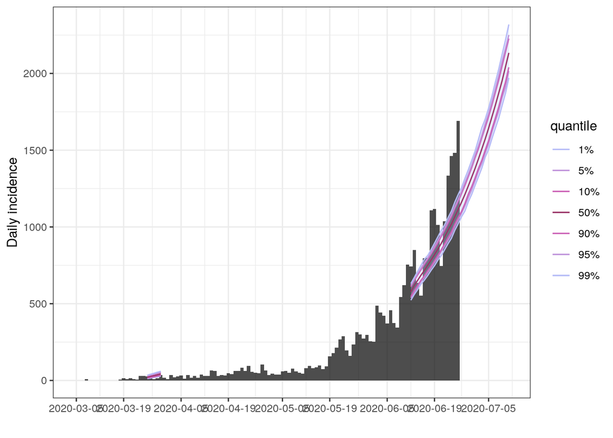

## Estimación de $R_t$ por provincia

- Utilizamos los datos abiertos del Ministerio de Salud. Las lineas rojas son el inicio de la quarentena y las fases del gobierno nacional.

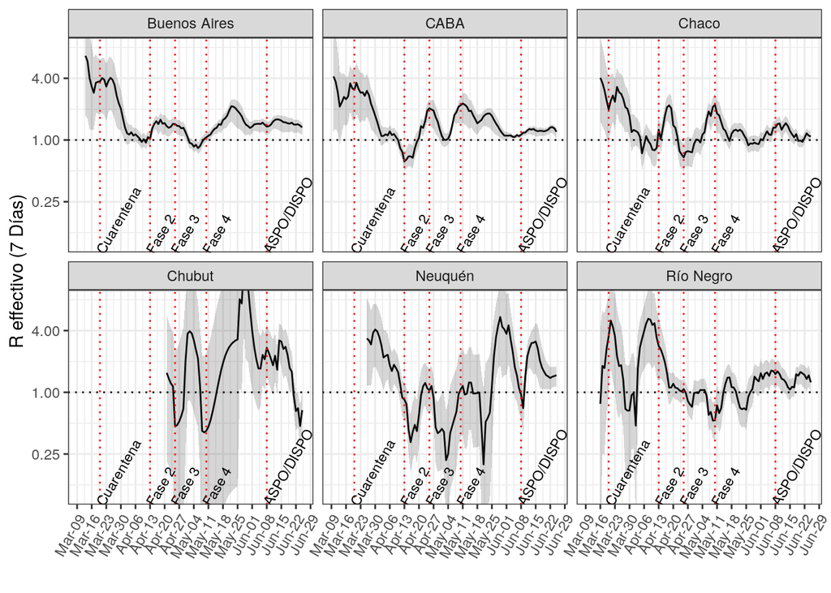

## Comparación de datos de Incidencia (nro. de casos por día) por Provincia

- Inicialmente utilizamos los datos abiertos del Ministerio de Salud. Las lineas rojas son el inicio de la quarentena y las fases del gobierno nacional.
- Los datos cargados a partir de los reportes del Ministerio de Salud, tienen diferencias con los “Datos abiertos del Ministerio de Salud” en este último caso utilizamos las fechas de diagnóstico y la provincia de residencia, cuando la provincia de residencia está SIN ESPECIFICAR se toma la provincia de carga.

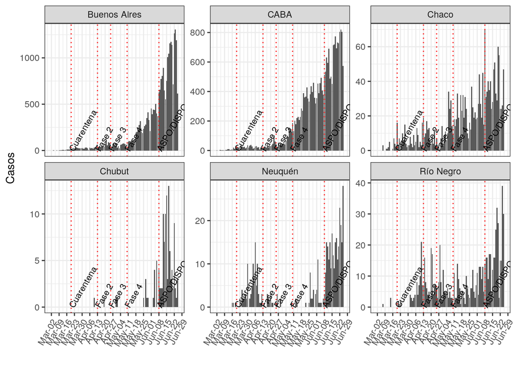

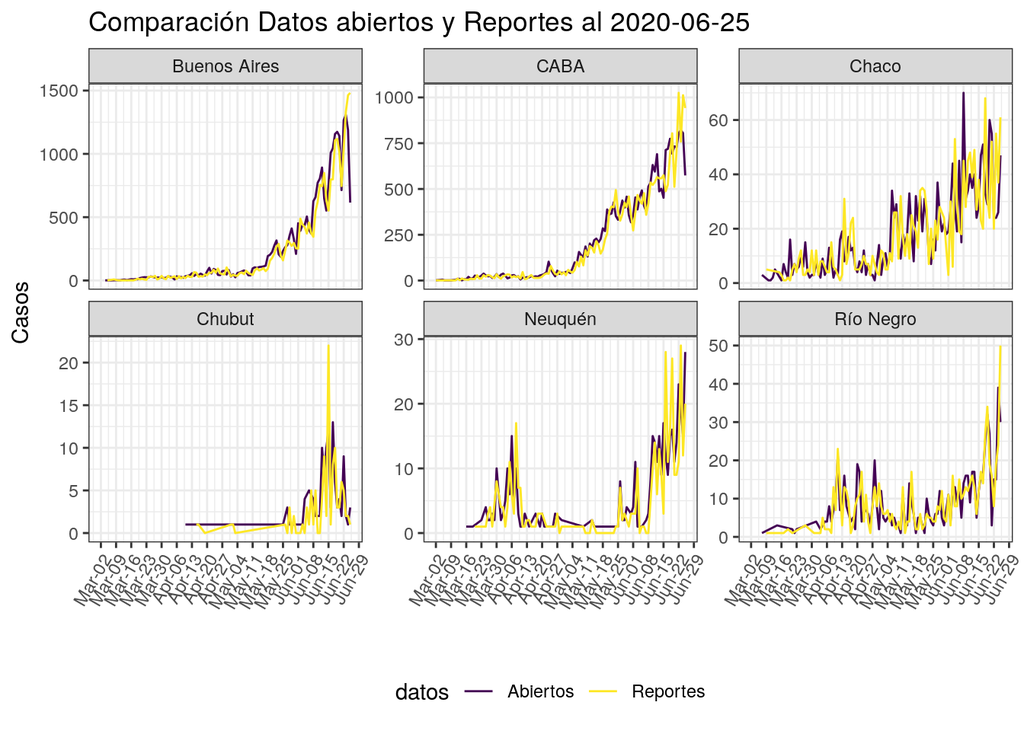

| residencia_provincia_nombre | fecha | Abiertos | Reportes |
| --- | --- | --- | --- |
| Buenos Aires | 2020-06-25 | 26046 | 24646 |
| CABA | 2020-06-25 | 23549 | 22745 |
| Chaco | 2020-06-25 | 1816 | 1755 |
| Chubut | 2020-06-25 | 115 | 104 |
| Neuquén | 2020-06-25 | 409 | 384 |
| Río Negro | 2020-06-25 | 797 | 792 |

## Parámetros a partir de Datos Abiertos por Provincia

- Arreglo provicia de residencia SIN ESPECIFICAR asumiendo provincia de carga
- Fallecidos sin fecha de hospitalización asumo que fueron hospitalizados.
- Calculo de días de hospitalización solamente para los fallecidos.
- Dias pre-hospitalización: desde inicio de síntomas hasta hospitalización.

Tabla 1: Fallecidos sin fecha de hospitalización

| residencia_provincia_nombre | edad | n | Porcentaje |
| --- | --- | --- | --- |
| Buenos Aires | 77 | 137 | 26 |
| CABA | 81 | 60 | 13 |
| Río Negro | 74 | 13 | 32 |
| Córdoba | 74 | 9 | 25 |
| Chaco | 47 | 3 | 3 |
| La Rioja | 86 | 3 | 38 |
| Chubut | 45 | 1 | 100 |
| Neuquén | 62 | 1 | 9 |

Tabla 2: TOTAL: Fallecidos sin fecha de hospitalización

| edad | n | Porcentaje |
| --- | --- | --- |
| 78 | 227 | 19.17 |

Tabla 3: Proporcion Fallecidos con respecto a hospitalizados

| residencia_provincia_nombre | edad | dias_hospitalizacion | dias_pre_hospitalizacion | n | Porcentaje |
| --- | --- | --- | --- | --- | --- |
| Buenos Aires | 74.0 | 7.0 days | 2.0 days | 526 | 10 |
| CABA | 76.0 | 10.0 days | 2.0 days | 447 | 7 |
| Chaco | 64.5 | 6.0 days | 5.0 days | 92 | 38 |
| Río Negro | 72.0 | 7.5 days | 1.0 days | 41 | 11 |
| Córdoba | 78.5 | 16.0 days | 3.0 days | 36 | 27 |
| Neuquén | 70.0 | 5.0 days | 2.5 days | 11 | 4 |
| Mendoza | 75.0 | 7.0 days | 5.0 days | 9 | 6 |
| La Rioja | 79.0 | 8.0 days | 3.0 days | 8 | 47 |
| Tucumán | 63.5 | 9.0 days | 3.0 days | 5 | 29 |
| Santa Fe | 65.5 | 18.0 days | 6.0 days | 4 | 6 |
| Misiones | 54.5 | 4.5 days | 2.0 days | 2 | 7 |
| Chubut | 45.0 | NA | NA | 1 | 20 |
| Jujuy | 52.0 | 16.0 days | 6.0 days | 1 | 50 |
| Tierra del Fuego | 79.0 | 23.0 days | 1.0 days | 1 | 14 |

Tabla 4: De Hospitalizados cuantos Fallecen y fueron a Cuidado Intensivo, o no

| residencia_provincia_nombre | fallecido | cuidado_intensivo | edad | dias_hospitalizacion | dias_pre_hospitalizacion | n | Porcentaje |
| --- | --- | --- | --- | --- | --- | --- | --- |
| Buenos Aires | NO | NO | 41.0 | NA | 2.0 days | 4504 | 92 |
| Buenos Aires | NO | SI | 59.0 | NA | 2.0 days | 367 | 8 |
| Buenos Aires | SI | NO | 77.0 | 7.0 days | 1.0 days | 324 | 62 |
| Buenos Aires | SI | SI | 70.5 | 7.0 days | 3.0 days | 202 | 38 |
| CABA | NO | NO | 39.0 | NA | 2.0 days | 5482 | 94 |
| CABA | NO | SI | 58.0 | NA | 3.0 days | 328 | 6 |
| CABA | SI | NO | 83.5 | 9.0 days | 2.0 days | 248 | 55 |
| CABA | SI | SI | 69.0 | 11.0 days | 3.0 days | 199 | 45 |
| Chaco | NO | NO | 50.0 | NA | 5.0 days | 91 | 59 |
| Chaco | NO | SI | 55.0 | NA | 5.0 days | 62 | 41 |
| Chaco | SI | NO | 68.0 | 5.0 days | 5.0 days | 23 | 25 |
| Chaco | SI | SI | 61.0 | 7.0 days | 5.0 days | 69 | 75 |
| Chubut | NO | NO | 62.0 | NA | 3.5 days | 3 | 75 |
| Chubut | NO | SI | 69.0 | NA | 11.0 days | 1 | 25 |
| Chubut | SI | NO | 45.0 | NA | NA | 1 | 100 |
| Córdoba | NO | NO | 70.5 | NA | 2.0 days | 76 | 79 |
| Córdoba | NO | SI | 64.0 | NA | 2.5 days | 20 | 21 |
| Córdoba | SI | NO | 81.0 | 13.0 days | 1.0 days | 26 | 72 |
| Córdoba | SI | SI | 72.5 | 18.5 days | 4.5 days | 10 | 28 |
| Corrientes | NO | NO | 85.0 | NA | 7.0 days | 1 | 100 |
| Entre Ríos | NO | NO | 36.0 | NA | 3.0 days | 67 | 100 |
| Jujuy | NO | NO | 41.0 | NA | NA | 1 | 100 |
| Jujuy | SI | SI | 52.0 | 16.0 days | 6.0 days | 1 | 100 |
| La Pampa | NO | NO | 71.0 | NA | 5.0 days | 1 | 100 |
| La Rioja | NO | NO | 45.0 | NA | 4.0 days | 9 | 100 |
| La Rioja | SI | NO | 83.0 | 2.0 days | 3.0 days | 4 | 50 |
| La Rioja | SI | SI | 72.0 | 12.0 days | 2.5 days | 4 | 50 |
| Mendoza | NO | NO | 34.0 | NA | 2.0 days | 130 | 96 |
| Mendoza | NO | SI | 64.0 | NA | 6.0 days | 5 | 4 |
| Mendoza | SI | NO | 75.0 | 8.0 days | 5.0 days | 3 | 33 |
| Mendoza | SI | SI | 74.5 | 4.5 days | 4.5 days | 6 | 67 |
| Misiones | NO | NO | 42.0 | NA | 0.0 days | 23 | 85 |
| Misiones | NO | SI | 60.5 | NA | 1.0 days | 4 | 15 |
| Misiones | SI | SI | 54.5 | 4.5 days | 2.0 days | 2 | 100 |
| Neuquén | NO | NO | 35.0 | NA | 2.0 days | 264 | 99 |
| Neuquén | NO | SI | 80.0 | NA | 0.0 days | 2 | 1 |
| Neuquén | SI | NO | 69.0 | 4.0 days | 1.0 days | 7 | 64 |
| Neuquén | SI | SI | 74.0 | 5.5 days | 4.0 days | 4 | 36 |
| Río Negro | NO | NO | 39.0 | NA | 2.0 days | 328 | 97 |
| Río Negro | NO | SI | 58.0 | NA | 2.0 days | 11 | 3 |
| Río Negro | SI | NO | 74.0 | 9.0 days | 1.0 days | 25 | 61 |
| Río Negro | SI | SI | 68.0 | 6.5 days | 1.0 days | 16 | 39 |
| Salta | NO | NO | 33.5 | NA | 5.0 days | 20 | 100 |
| San Juan | NO | NO | 43.0 | NA | 4.0 days | 4 | 80 |
| San Juan | NO | SI | 63.0 | NA | 5.0 days | 1 | 20 |
| San Luis | NO | NO | 30.0 | NA | 4.0 days | 7 | 88 |
| San Luis | NO | SI | 62.0 | NA | 3.0 days | 1 | 12 |
| Santa Cruz | NO | NO | 49.0 | NA | 2.0 days | 18 | 78 |
| Santa Cruz | NO | SI | 64.0 | NA | 2.0 days | 5 | 22 |
| Santa Fe | NO | NO | 55.0 | NA | 3.0 days | 52 | 84 |
| Santa Fe | NO | SI | 69.5 | NA | 3.5 days | 10 | 16 |
| Santa Fe | SI | SI | 65.5 | 18.0 days | 6.0 days | 4 | 100 |
| Santiago del Estero | NO | SI | 29.0 | NA | 9.0 days | 1 | 100 |
| Tierra del Fuego | NO | NO | 40.5 | NA | 3.0 days | 4 | 67 |
| Tierra del Fuego | NO | SI | 62.5 | NA | 10.0 days | 2 | 33 |
| Tierra del Fuego | SI | SI | 79.0 | 23.0 days | 1.0 days | 1 | 100 |
| Tucumán | NO | NO | 32.0 | NA | 2.0 days | 6 | 50 |
| Tucumán | NO | SI | 24.0 | NA | 5.0 days | 6 | 50 |
| Tucumán | SI | NO | 66.0 | 10.0 days | 2.0 days | 1 | 20 |
| Tucumán | SI | SI | 61.0 | 8.5 days | 3.0 days | 4 | 80 |

Tabla 5: Proporción Hospitalizados con respecto a casos

| residencia_provincia_nombre | edad | n | Porcentaje |
| --- | --- | --- | --- |
| CABA | 43.0 | 6257 | 26 |
| Buenos Aires | 45.0 | 5397 | 21 |
| Río Negro | 42.0 | 380 | 47 |
| Neuquén | 37.0 | 277 | 67 |
| Chaco | 57.0 | 245 | 13 |
| Mendoza | 37.0 | 144 | 93 |
| Córdoba | 72.5 | 132 | 22 |
| Entre Ríos | 36.0 | 67 | 28 |
| Santa Fe | 61.0 | 66 | 16 |
| Misiones | 50.0 | 29 | 71 |
| Santa Cruz | 51.0 | 23 | 44 |
| Salta | 33.5 | 20 | 80 |
| La Rioja | 57.0 | 17 | 23 |
| Tucumán | 33.5 | 17 | 24 |
| San Luis | 37.0 | 8 | 73 |
| Tierra del Fuego | 50.0 | 7 | 5 |
| Chubut | 62.0 | 5 | 4 |
| San Juan | 44.0 | 5 | 62 |
| Jujuy | 46.5 | 2 | 3 |
| Corrientes | 85.0 | 1 | 1 |
| La Pampa | 71.0 | 1 | 14 |
| Santiago del Estero | 29.0 | 1 | 4 |

Tabla 6: Letalidad Proporción Fallecidos con respecto a casos

| residencia_provincia_nombre | n | Porcentaje |
| --- | --- | --- |
| Buenos Aires | 526 | 2 |
| CABA | 447 | 2 |
| Chaco | 92 | 5 |
| Río Negro | 41 | 5 |
| Córdoba | 36 | 6 |
| Neuquén | 11 | 3 |
| Mendoza | 9 | 6 |
| La Rioja | 8 | 11 |
| Tucumán | 5 | 7 |
| Santa Fe | 4 | 1 |
| Misiones | 2 | 5 |
| Chubut | 1 | 1 |
| Jujuy | 1 | 1 |
| Tierra del Fuego | 1 | 1 |

Tabla 7: TOTAL: Proporcion Fallecidos con respecto a hospitalizados

| fallecido | edad | dias_hospitalizacion | dias_pre_hospitalizacion | n | Porcentaje |
| --- | --- | --- | --- | --- | --- |
| NO | 42 | NA | 2 days | 11917 | 90.96 |
| SI | 74 | 8 days | 2 days | 1184 | 9.04 |

Tabla 8: TOTAL: Proporcion Cuidado Intensivo con respecto a hospitalizados

| cuidado_intensivo | edad | dias_hospitalizacion | dias_pre_hospitalizacion | n | Porcentaje |
| --- | --- | --- | --- | --- | --- |
| NO | 42 | 8 days | 2 days | 11753 | 89.71 |
| SI | 63 | 8 days | 3 days | 1348 | 10.29 |

Tabla 9: TOTAL: De Hospitalizados cuantos Fallecen y fueron a Cuidado Intensivo, o no

| fallecido | cuidado_intensivo | edad | dias_hospitalizacion | dias_pre_hospitalizacion | n | Porcentaje |
| --- | --- | --- | --- | --- | --- | --- |
| NO | NO | 40 | NA | 2 days | 11091 | 93.07 |
| NO | SI | 58 | NA | 3 days | 826 | 6.93 |
| SI | NO | 78 | 8 days | 2 days | 662 | 55.91 |
| SI | SI | 69 | 8 days | 3 days | 522 | 44.09 |

Tabla 10: TOTAL: De Cuidado intensivo cuantos Fallecen

| fallecido | edad | dias_hospitalizacion | dias_pre_hospitalizacion | n | Porcentaje |
| --- | --- | --- | --- | --- | --- |
| NO | 59 | NA | 3 days | 843 | 61.76 |
| SI | 69 | 8 days | 3 days | 522 | 38.24 |

Tabla 11: Letalidad Proporción Fallecidos con respecto a casos

| fallecido | n | Porcentaje |
| --- | --- | --- |
| NO | 54034 | 97.86 |
| SI | 1184 | 2.14 |

Tabla 12: Proporción Hospitalizados con respecto a casos

| edad | n | Porcentaje |
| --- | --- | --- |
| 44 | 13101 | 24 |

## Bibliografía

Cori, Anne, Neil M. Ferguson, Christophe Fraser, and Simon Cauchemez. 2013. “A New Framework and Software to Estimate Time-Varying Reproduction Numbers During Epidemics.” *American Journal of Epidemiology* 178 (9): 1505–12. doi:10.1093/aje/kwt133.

He, Xi, Eric H. Y. Lau, Peng Wu, Xilong Deng, Jian Wang, Xinxin Hao, Yiu Chung Lau, et al. 2020. “Temporal Dynamics in Viral Shedding and Transmissibility of COVID-19.” *Nature Medicine*, April. Nature Publishing Group, 1–4. doi:10.1038/s41591-020-0869-5.

Hébert-Dufresne, Laurent, Benjamin M. Althouse, Samuel V. Scarpino, and Antoine Allard. 2020. “Beyond R0: Heterogeneity in Secondary Infections and Probabilistic Epidemic Forecasting,” April. http://arxiv.org/abs/2002.04004.

Kermack, William Ogilvy, A. G. McKendrick, and Gilbert Thomas Walker. 1927. “A Contribution to the Mathematical Theory of Epidemics.” *Proceedings of the Royal Society of London. Series A, Containing Papers of a Mathematical and Physical Character* 115 (772). Royal Society: 700–721. doi:10.1098/rspa.1927.0118.

Li, Qun, Xuhua Guan, Peng Wu, Xiaoye Wang, Lei Zhou, Yeqing Tong, Ruiqi Ren, et al. 2020. “Early Transmission Dynamics in Wuhan, China, of Novel Coronavirus–Infected Pneumonia.” *New England Journal of Medicine* 382 (13). Massachusetts Medical Society: 1199–1207. doi:10.1056/NEJMoa2001316.

Lloyd-Smith, J. O., S. J. Schreiber, P. E. Kopp, and W. M. Getz. 2005. “Superspreading and the Effect of Individual Variation on Disease Emergence.” *Nature* 438 (7066, 7066). Nature Publishing Group: 355–59. doi:10.1038/nature04153.

Nouvellet, Pierre, Anne Cori, Tini Garske, Isobel M. Blake, Ilaria Dorigatti, Wes Hinsley, Thibaut Jombart, et al. 2018. “A Simple Approach to Measure Transmissibility and Forecast Incidence.” *Epidemics* 22 (March): 29–35. doi:10.1016/j.epidem.2017.02.012.

Thompson, R. N., J. E. Stockwin, R. D. van Gaalen, J. A. Polonsky, Z. N. Kamvar, P. A. Demarsh, E. Dahlqwist, et al. 2019. “Improved Inference of Time-Varying Reproduction Numbers During Infectious Disease Outbreaks.” *Epidemics* 29 (December): 100356. doi:10.1016/j.epidem.2019.100356.